# Plate reader growth curves of GAT204, LIV3 and double deletion mutants

Liz Hughes & Edward Wallace

05/04/2024

# Summary

This experiments tests the effect of gat204∆, liv3∆, and the double deletion, on C. neoformans growth in RPMI media. It uses wild-type strain and gat201∆ as controls.

This concludes that (again) both gat204∆ and liv3∆ alone have intermediate growth phenotype between wild-type and gat201∆ cells. New here, the double deletion mutant gat204∆liv3∆ has an intermediate phenotype similar to both those single mutants.

Data in files, one per biological replicate plate:

- `20240403_GAT204LIV3.xlsx`

# Set up data frame of nice strain names, colours, styles.

```r
strain_df <- tibble( Strain      = c("KN99-1", "Gat201(M)", "Gat204", "Liv3", "Gat201-Liv3"),
                     Strain_nice = c("WT", "gat201∆", "gat204∆", "liv3∆", "gat204∆liv3∆"),
                     colour      = c("grey20", "darkred", "#d95f02", "#1b9e77",   "purple"))
```

## Read in the Plate map data from csv file RPMI

Also combine with nice strain names for display.

```r
platemap <-
  here::here("data", "20240403_GAT204LIV3_Setup.csv") %>%
  read_platemap_csv(strain_df = strain_df)

head(platemap, n=10)
```

```
## # A tibble: 10 × 7
##    Well  Strain Biorep Techrep Medium Strain_nice colour
##    <chr> <chr>   <dbl>   <dbl> <chr>  <chr>       <chr>
##  1 A1    <NA>       NA      NA RPMI   <NA>        <NA>
##  2 A2    <NA>       NA      NA RPMI   <NA>        <NA>
##  3 A3    <NA>       NA      NA RPMI   <NA>        <NA>
##  4 A4    <NA>       NA      NA RPMI   <NA>        <NA>
##  5 A5    <NA>       NA      NA RPMI   <NA>        <NA>
##  6 A6    <NA>       NA      NA RPMI   <NA>        <NA>
##  7 A7    <NA>       NA      NA RPMI   <NA>        <NA>
##  8 A8    <NA>       NA      NA RPMI   <NA>        <NA>
##  9 A9    <NA>       NA      NA RPMI   <NA>        <NA>
## 10 A10   <NA>       NA      NA RPMI   <NA>        <NA>
```

# Analysis, biological replicate 1

## Read in raw data

```r
raw_od <-
  here::here("data", "20240403_GAT204LIV3.xlsx") %>%
  read_platereader_xlsx_magellan(well_names = well_names_96_colfirst)
```

## Reshape data and combine with the plate map, pairing them by Well

```r
annotated_od <-
  reshape_annotate_raw_od(raw_od = raw_od, platemap = platemap) %>%
  mutate(Well = factor(Well, levels = well_names_96_rowfirst))
```

## Plot ODs from all wells

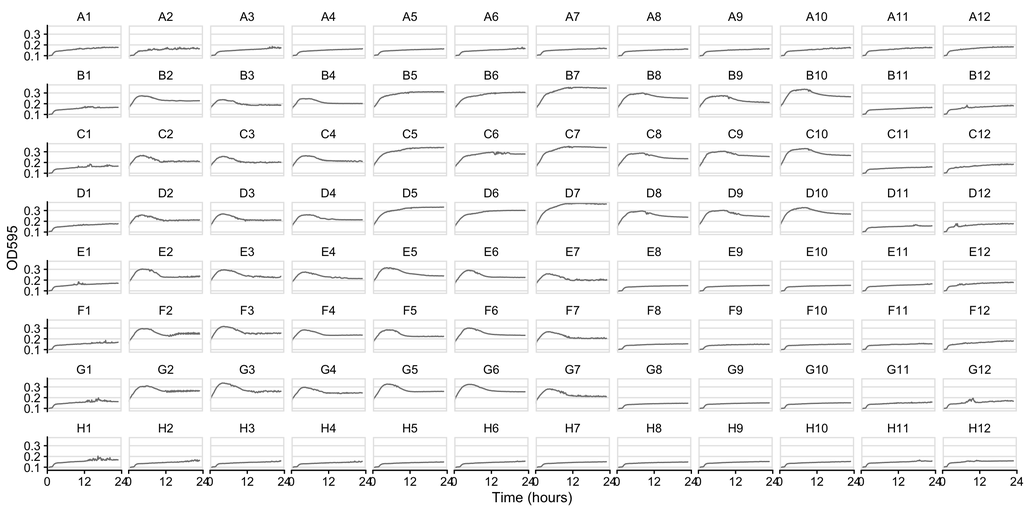

```r
ggplot(data=annotated_od,
       aes(x=Time, y=OD595,  group = Well, colour = Strain)) +
  geom_line() +
  scale_time_hrs(limits = c(0,24)) +
  scale_color_strain(strain_df) +
  facet_wrap(~ Well, ncol = 12)
```

## Plot blank ODs

To find how stable the ODs of the blank wells are.

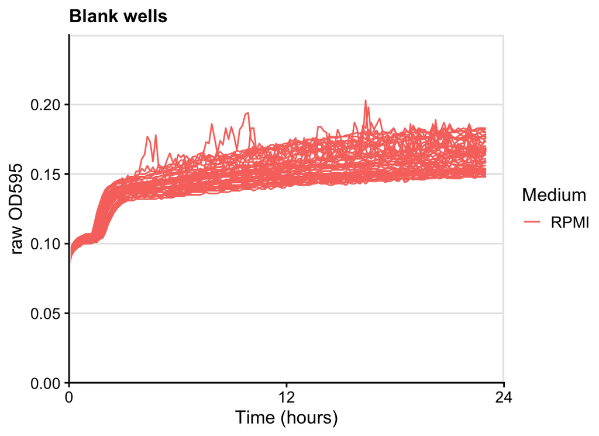

```r
ggplot(data=filter(annotated_od, is.na(Strain)),
       aes(x=Time, y=OD595,  group = Well, colour = Medium)) +
  geom_line() +
  scale_time_hrs(limits = c(0,24)) +
  scale_y_continuous(limits = c(0, 0.25),
                     expand = c(0, 0),
                     breaks = c(0, 0.05, 0.1, 0.15, 0.2)) +
  labs(title = "Blank wells", x="Time (hours)", y="raw OD595")
```

This shows that OD of blank wells is somewhat messy, but within reasonable bounds.

## Calculate median OD for blank wells

```r
blank_od_summary <-
  annotated_od %>%
  dplyr::group_by(Medium) %>%
  summarise_od_fixed(od.name = "OD595",
                     is.na(Strain))

print(blank_od_summary)
```

```
## # A tibble: 1 × 5
## # Groups:   Medium [1]
##   Medium OD_median OD_mean OD_max OD_min
##   <chr>      <dbl>   <dbl>  <dbl>  <dbl>
## 1 RPMI       0.149   0.148  0.203  0.085
```

```r
blank_od_time <-
  annotated_od %>%
  dplyr::group_by(Medium) %>%
  summarise_od_bytime(od.name = "OD595",
                     is.na(Strain),
                     !is.na(OD595))

print(blank_od_time)
```

[output not shown]

## Subtract blank OD to make corrected OD

```r
normalised_od <-
  annotated_od %>%
  normalise_od_2ways(is.na(Strain))
```

## Plot OD corrected

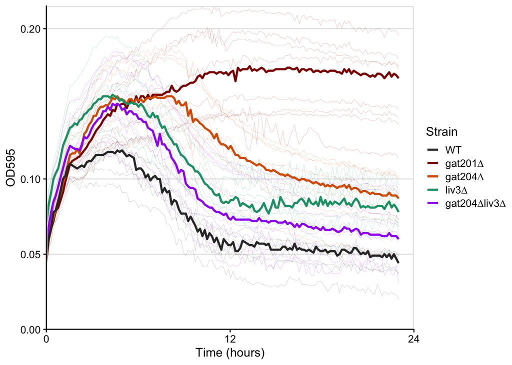

```r
plot <-
  ggplot_growthcurve_summary(data_od = normalised_od %>%
                               filter(!is.na(Strain)),
                             value_od = "OD_corrected_time",
                             limits_time = c(0,24),
                             limits_od = NULL,
                             breaks_od = c(0, 0.05, 0.1, 0.2, 0.3, 0.4, 0.5)) +
  scale_color_strain(strain_df) +
  expand_limits(y = c(0, 0.12))

plot
```

## Plot OD corrected, with smoothing spline

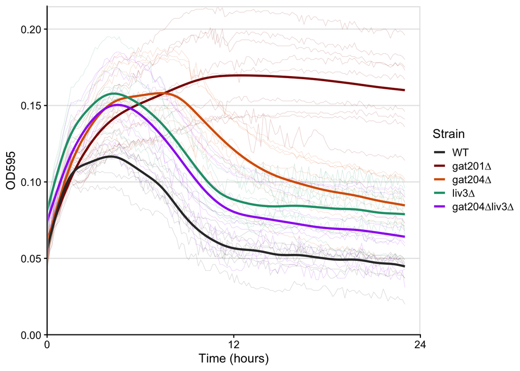

```r
spline_plot <-
  ggplot_growthcurve_spline_pluswells(
    data_od = normalised_od %>%
      filter(!is.na(Strain)),
    value_od = "OD_corrected_time",
    limits_time = c(0,24),
    limits_od = NULL,
    breaks_od = c(0, 0.05, 0.1, 0.15, 0.2)
  ) +

  scale_color_strain(strain_df) +
  expand_limits(y = c(0, 0.2))

spline_plot
```

```r
ggsave(filename = here::here("results", "fig_growthcurves_GAT204_LIV3.png"),
       plot = spline_plot, height = 3.5, width = 5)
```